# statistics stuff to think about

9 November 2022

## outline

- experimental design
- statistical philosophy
- statistical tests & assumptions
- analysis platforms

## the most important thing

- Design your experiment well and execute it well:  
  don’t have to worry much about statistics
- Don’t: you’re doomed - statistics can’t save you
- **randomization**, **replication**, **control**

## randomization

- random *assignment to treatments*
- poorer alternative: *haphazard* assignment  
  (“convenience sampling”)
- stratification  
  (i.e., randomize within groups)
- related: experimental *blinding*

## Yellowstone aspen regeneration

> Brice et al. (2022): Understanding trophic cascades in terrestrial wildlife communities is a major challenge because these systems are difficult to sample properly. We show how a tradition of non-random sampling has confounded this understanding in a textbook system (Yellowstone National Park) …

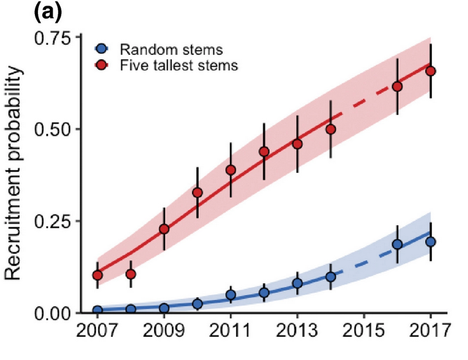

## replication

- how big does your experiment need to be?
- **power**: probability of detecting an effect of a particular size,  
  if one exists
- more generally: how much information? what kinds of mistakes? (Gelman and Carlin 2014)
- *underpowered* studies
  - failure is likely
  - cheating is likely
  - *significance filter* \(\to\) biased estimates
- *overpowered* studies waste time, lives, $$$

## power analysis

- need to guess *effect size* and variability
  - minimum *interesting* biological effect size
  - previous studies
  - ask your supervisor
- OK to simplify design (e.g. ANOVA \(\to\) \(t\)-test)
- methods
  - seat-of-the-pants
  - [web calculators](http://homepage.stat.uiowa.edu/~rlenth/Power/)
  - in R

```r
apropos("^power")  ## base-R functions
library("sos"); findFn("{power analysis}")
```

## power analysis example

With \(n=15\) per group, are we likely to see a clear difference between 10% (control) and 20% (treatment) mortality (a **doubling** of mortality)?

- `PollEv.com/bbolker2234`
- Text `BBOLKER2234` to `22333` once to join

[link](https://www.polleverywhere.com/multiple_choice_polls/ezjaxEkbvqJIiOnFFckQs)

## power analysis example (continued)

```r
power.prop.test(n=15, p1=0.1, p2=0.2)
```

```
##
##      Two-sample comparison of proportions power calculation
##
##               n = 15
##              p1 = 0.1
##              p2 = 0.2
##       sig.level = 0.05
##           power = 0.1141268
##     alternative = two.sided
##
## NOTE: n is number in *each* group
```

**Uh-oh!**

How many samples per group would we need to get power=0.8?

[link](https://www.polleverywhere.com/multiple_choice_polls/V1xRAqc4sf9UHBCGWYTz3)

```r
power.prop.test(power=0.8, p1=0.1, p2=0.2, sig.level=0.05)
```

```
##
##      Two-sample comparison of proportions power calculation
##
##               n = 198.9634
##              p1 = 0.1
##              p2 = 0.2
##       sig.level = 0.05
##           power = 0.8
##     alternative = two.sided
##
## NOTE: n is number in *each* group
```

**Uh-oh!**

[**what should we do?**](https://www.polleverywhere.com/discourses/cyA0PTPQA1nI3Qb198idK)

## increasing power (control)

- increasing sample size … **is not the only option**
- increase rejection threshold (e.g. \(\alpha=0.1\))
- maximize **treatment** variation (e.g. large doses)
- measure a clearer outcome (gene expression, hormone levels, etc.)
- **ask a different (simpler) question**
- minimize **non-treatment** variation
  - *within-subjects* designs  
    (paired, randomized-block, crossover)
- minimize environmental variation  
  (e.g. environmental chambers; clonal or inbred lines)
- isolate desired effects: **positive/negative controls**  
  (vehicle-only, cage treatments, etc.)
- control for variation statistically  
  (e.g. include body size as a covariate)

## statistical philosophy

[figure not shown]

## the other most important thing

- **don’t snoop!**  
  (i.e don’t look at your results  
  **before deciding how to analyze them**)
- (but **do** explore your data graphically after deciding on a tentative analysis plan!)
- reproducibility crisis: Ioannidis (2005); Simmons et al. (2011) (“researcher degrees of freedom”); Gelman and Loken (2014) (“the garden of forking paths”)
- pre-register; think about what your questions are and how you will test them **before you look at your data**

## do plot your data …

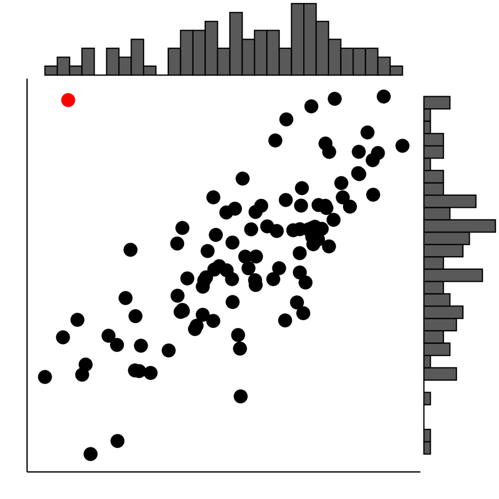

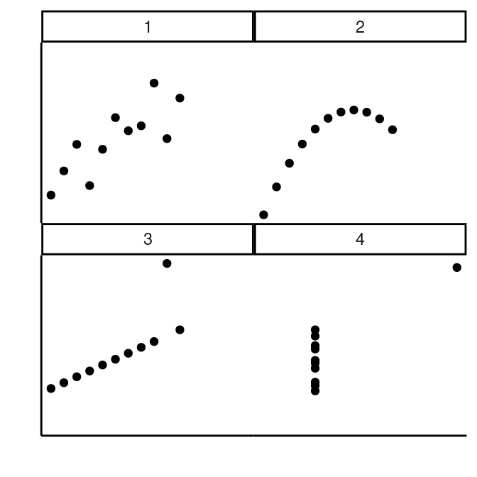

“Anscombe’s quartet”; see also “Datasaurus” (Matejka et al. 2017)

## don’t lean on p-values too much

- eschew vacuous hypotheses
- don’t accept the null hypothesis
- “the difference between significant and non-significant is not significant” (Gelman et al. 2006)
- statistical *clarity* (Dushoff et al. 2019)
- [link](https://www.polleverywhere.com/multiple_choice_polls/Xnq70HYpOp6LZObg7KBG3)

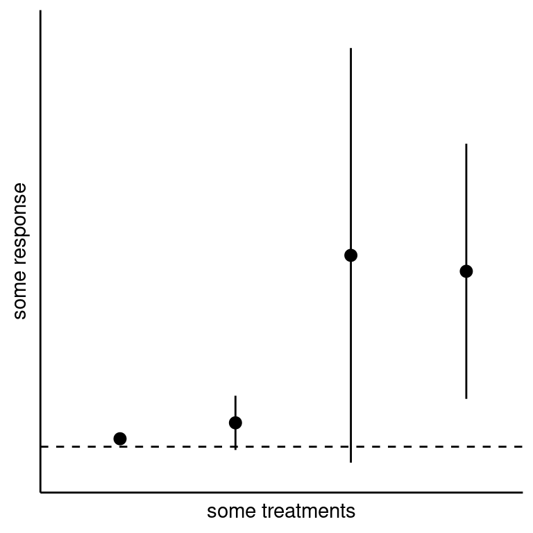

## don’t lean on p-values too much

- focus on effect sizes/CIs
- eschew vacuous hypotheses
- don’t accept the null hypothesis
- “the difference between significant and non-significant is not significant” (Gelman et al. 2006)
- statistical *clarity* (Dushoff et al. 2019)

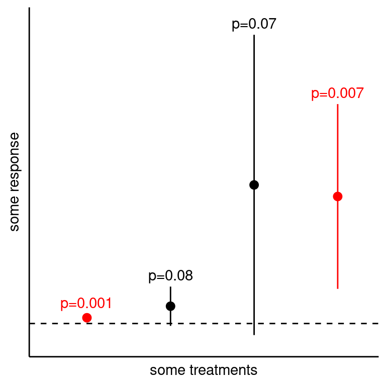

## focus on effect sizes: regression table

1978 automobile data (Chambers et al. 2018)

|  | (1) |  |
| --- | --- | --- |
| (Intercept) | 8.010 | (6.206) |
| mpg | -0.187 * | (0.088) |
| trunk | -0.013 | (0.105) |
| length | 0.055 | (0.036) |
| turn | -0.200 | (0.140) |
| N | 74 |  |
| R2 | 0.251 |  |
| logLik | -173.832 |  |
| AIC | 359.665 |  |
| *** p < 0.001; ** p < 0.01; * p < 0.05. |  |  |

## focus on effect sizes: coefficient plot

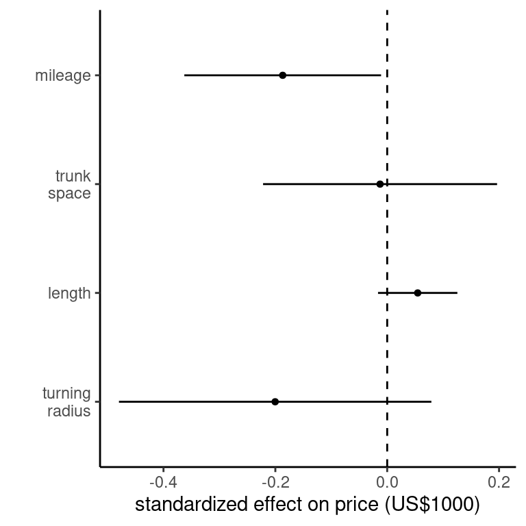

## statistical tests

## assumptions

- independence (hard to test!)
- homogeneity of variance (vs. *heteroscedasticity*)
- linearity
- Normality (*least* important)
  - outliers; skew; “fat tails” (Student 1927)
  - distributional assumptions apply to the *conditional distribution* of the response variable

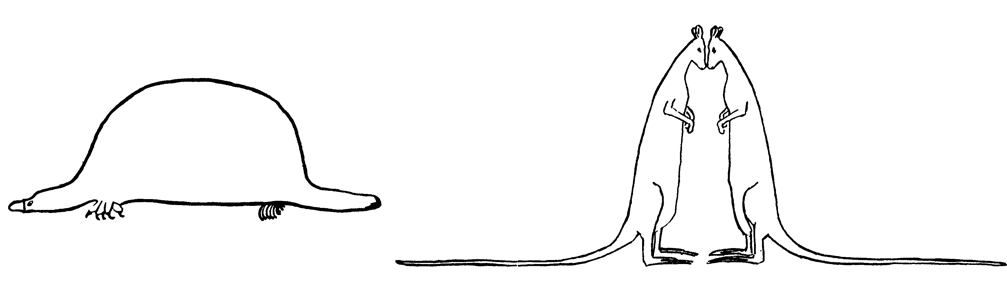

## diagnostics

- hypothesis tests are generally **not** appropriate:  
  they answer the wrong question
- graphical diagnostics, e.g.
  - residuals plots (linearity, heteroscedasticity)
  - influence plots (outliers)
  - Q-Q plots (Normality)

## (the data set)

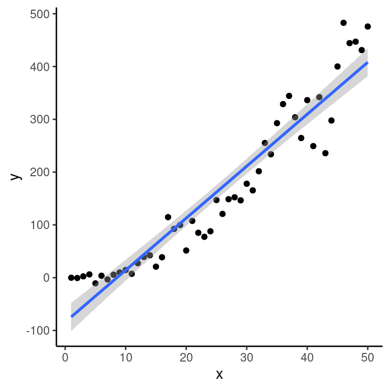

## diagnostics (`performance` pkg)

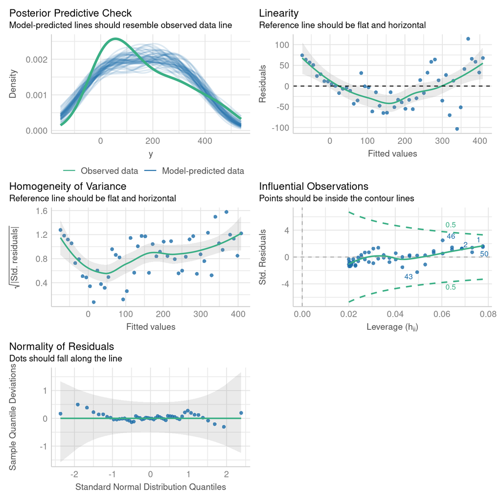

## fix the model

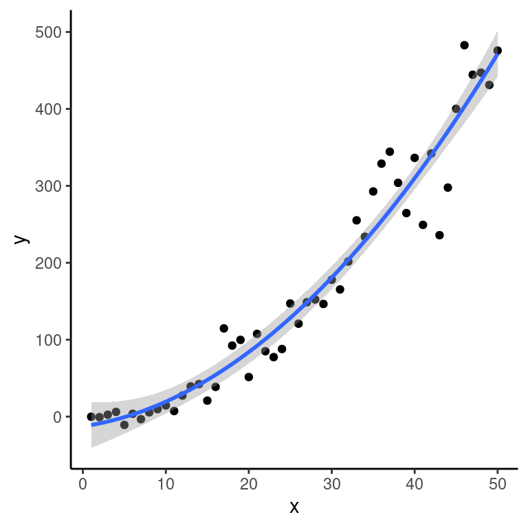

## new check

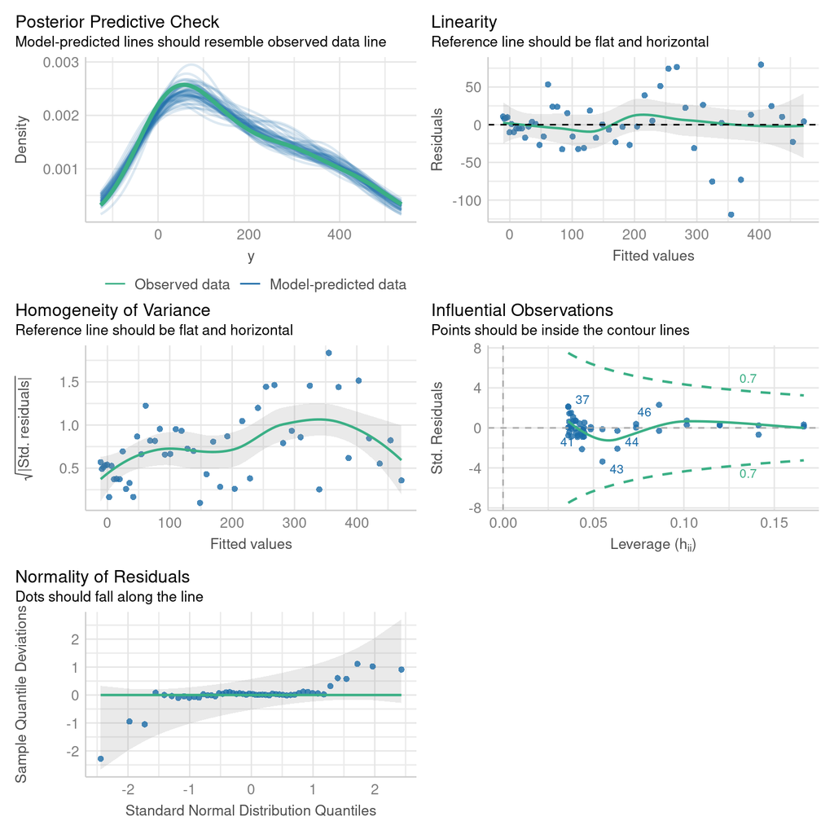

## dealing with violations

- drop outliers (report both analyses)
- transform (e.g. log transform: *Box-Cox* analysis)
- non-parametric (rank-based) tests  
  (e.g. Mann-Whitney-Wilcoxon, Kruskal-Wallis)
- relax assumptions/do fancier stats, e.g.
  - logistic regression (binary outcomes)
  - quadratic regression (nonlinearity)

## what should you use?

- connect scientific & statistical questions
- data type
  - see [decision tree](http://www.tnstate.edu/eduadmin/StatisticsDecisionTree%20Use.pdf) or [table](http://www.ats.ucla.edu/stat/mult_pkg/whatstat/default.htm)
  - if your question *doesn’t* fit in this tree,  
    think about how much you like statistics …
- nonparametric stats
  - slight loss of power
  - stronger assumptions than you think
  - \(p\)-values only - no effect size

## computational platforms

## Criteria

- simple/weak vs. complex/powerful
- GUI vs command-line
- **default:** use what your lab uses

## Excel

- ubiquitous
- open alternatives (Open Office)
- data in plain sight
- good enough for simple stuff
- occasional traps (McCullough et al. (2008); date handling; etc. Ziemann et al. (2016))
- **archive your data as CSV, not XLSX**

## stats packages

- SPSS, JMP …
- more reliable than Excel
- more powerful than Excel
- point & click (mostly)

## R

- powerful; free & open
- reproducible: script-based
- hardest to learn
- graphical interfaces: [R Commander](http://socserv.mcmaster.ca/jfox/Misc/Rcmdr/) or [Jamovi](https://www.jamovi.org/)
- great for data manipulation, graphics  
  (once you learn how)

## t-test (R)

```r
x1 = c(1.5,2.5,2.1)
x2 = c(1.1,1.4,1.5)
t.test(x1,x2)
```

```
##
##  Welch Two Sample t-test
##
## data:  x1 and x2
## t = 2.226, df = 2.6648, p-value = 0.1236
## alternative hypothesis: true difference in means is not equal to 0
## 95 percent confidence interval:
##  -0.3759079  1.7759079
## sample estimates:
## mean of x mean of y
##  2.033333  1.333333
```

## t-test (Excel)

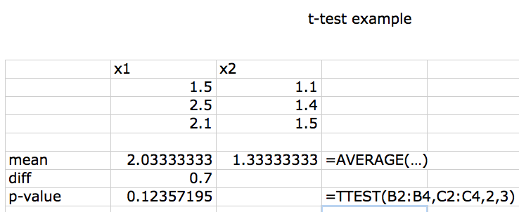

## Further resources

- *Nature* web collection, [“Statistics for Biologists”](http://www.nature.com/collections/qghhqm)
- [UCLA statistics consulting](http://stats.idre.ucla.edu/other/dae) (many examples in SAS, SPSS, R …)
- [CrossValidated](http://stats.stackexchange.com)
- [bio data lunch](https://mailman.mcmaster.ca/mailman/listinfo/biodatalunch-l)
- [source code for this talk](https://github.com/bbolker/bbmisc/tree/master/thesis_stats)

## References

Brice, EM et al. 2022. *Ecology Letters* 25 (1): 177–188. doi:10.1111/ele.13915. https://onlinelibrary.wiley.com/doi/abs/10.1111/ele.13915.

Chambers, JM et al. 2018. *Graphical methods for data analysis*. Chapman; Hall/CRC.

Dushoff, J et al. 2019. *Methods in Ecology and Evolution* 10 (6): 756–759. doi:10.1111/2041-210X.13159.

Gelman, A et al. 2006. *The American Statistician* 60 (4) (November): 328–331. doi:10.1198/000313006X152649. http://www.tandfonline.com/doi/abs/10.1198/000313006X152649.

Gelman, A, and E Loken. 2014. *American Scientist* 102 (6): 460–. http://link.galegroup.com/apps/doc/A389260653/AONE?u=ocul_mcmaster&sid=AONE&xid=4f4562c0.

Gelman, A, and J Carlin. 2014. *Perspectives on Psychological Science* 9 (6) (November): 641–651. doi:10.1177/1745691614551642. http://pps.sagepub.com/content/9/6/641.

Ioannidis, JPA. 2005. *PLoS Med* 2 (8): e124. doi:10.1371/journal.pmed.0020124. http://dx.doi.org/10.1371/journal.pmed.0020124.

Matejka, J et al. 2017. In. doi:10.1145/3025453.3025912. https://www.autodeskresearch.com/publications/samestats.

McCullough, BD et al. 2008. *Computational Statistics & Data Analysis* 52 (10) (June): 4570–4578. doi:10.1016/j.csda.2008.03.004. http://www.sciencedirect.com/science/article/pii/S0167947308001606.

Simmons, JP et al. 2011. *Psychological Science* 22 (11) (November): 1359–1366. doi:10.1177/0956797611417632. http://pss.sagepub.com/content/22/11/1359.

Student. 1927. *Biometrika* 19 (1/2) (July): 151–164. doi:10.2307/2332181. http://www.jstor.org/stable/2332181.

Ziemann, M et al. 2016. *Genome Biology* 17 (1) (August): 177. doi:10.1186/s13059-016-1044-7.